# Assignment 2: Distributions and Proportions Part 1

Julia Meinhardt

9/15/2020

```r
library(ggplot2)
library(tidyverse)
library(ggthemes)
```

### Reading csv, filtering by region, and attaching.

```r
Jefferson_tract_data <- read_csv("jeffersonbay2018.csv") %>%
  filter(region == "Jefferson")
attach(Jefferson_tract_data)
```

### Assignment Deliverables

For each continuous variable in your dataset calculate:

1.sample mean 2.sample standard deviation 3.95-percent confidence interval for the population mean 4.interquartile range.

Create a histogram to illustrate the distribution of each variable and describe the distribution in a sentence or two.

For each categorical variable in your dataset calculate: 1.95-percent confidence interval for the proportion of the population in each category

**List of Variables**

1.**female_popE** (continuous) 2.**male_popE** (continuous)

3.**poverty_100** : total below 100% poverty level (continuous) 4.**poverty_149** : total from 100 to 149% of poverty Level (continuous) 5.**poverty_150** : total at or above 150% of poverty level (continuous)

6.**public_assist** : households receiving public assistance (including ss) (continuous) 7.**cash_assist** : households receiving public assistance, cash and food stamps (continuous) 8.**no_assist** (continuous)

9.**majority_hs_grads** (categorical)

10. **county** (categorical)
11. **region** (categorical)

## Calculations and Distributions for Jefferson Region

This file is comprised of all the data calculaitons for the Jefferson Region of my dataset. The Bay Region calculations and distributions are done in a second file.

### Female Pop Summary Stats and Distribution

```r
summary(female_popE)
```

```
##    Min. 1st Qu.  Median    Mean 3rd Qu.    Max.
##       0    1002    1622    1645    2138    3613
```

```r
sd(female_popE)
```

```
## [1] 810.4473
```

```r
pop_mean1 <- t.test(female_popE)
pop_mean1
```

```
##
##  One Sample t-test
##
## data:  female_popE
## t = 19.787, df = 94, p-value < 2.2e-16
## alternative hypothesis: true mean is not equal to 0
## 95 percent confidence interval:
##  1480.209 1810.402
## sample estimates:
## mean of x
##  1645.305
```

```r
hist1 <- ggplot(Jefferson_tract_data, aes(x = female_popE)) +
  geom_histogram()
```

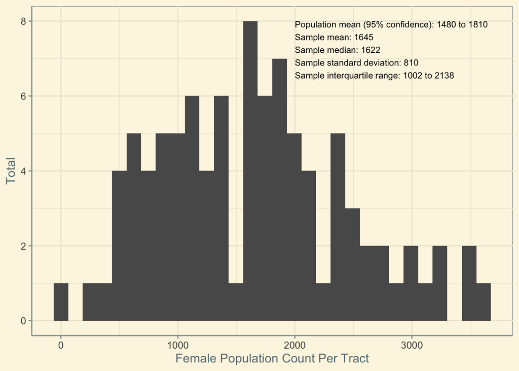

```r
hist1+
  theme_solarized() +
  scale_x_continuous(name = "Female Population Count Per Tract") +
  scale_y_continuous(name = "Total") +
  annotate("text", x = 2000, y = 8, size = 3,
           label = paste("Population mean (95% confidence):",
                         prettyNum(pop_mean1$conf.int[1], digits = 0),
                         "to",
                         prettyNum(pop_mean1$conf.int[2], digits = 0),

                         "\nSample mean:",
                         prettyNum(mean(female_popE), digits = 0),
                         "\nSample median:",
                         prettyNum(median(female_popE), digits = 0),
                         "\nSample standard deviation:",
                         prettyNum(sd(female_popE), digits = 0),
                         "\nSample interquartile range:",
                         prettyNum(quantile(female_popE)["25%"], digits = 0),
                         "to",
                         prettyNum(quantile(female_popE)["75%"], digits = 0)),
           hjust = 0, vjust = 1)
```

This distribution looks fairly normal, though the dips at 1500 and 2300 are distinct. There are only around 100 observations in the dataset for Jefferson, which makes for less smooth curves than my Bay datset.

### Male Pop Summary Stats and Distribution

```r
summary(male_popE)
```

```
##    Min. 1st Qu.  Median    Mean 3rd Qu.    Max.
##       0    1056    1661    1741    2191    8829
```

```r
sd(male_popE)
```

```
## [1] 1073.035
```

```r
pop_mean2 <- t.test(male_popE)
pop_mean2
```

```
##
##  One Sample t-test
##
## data:  male_popE
## t = 15.817, df = 94, p-value < 2.2e-16
## alternative hypothesis: true mean is not equal to 0
## 95 percent confidence interval:
##  1522.770 1959.946
## sample estimates:
## mean of x
##  1741.358
```

```r
hist2 <- ggplot(Jefferson_tract_data, aes(x = male_popE)) +
  geom_histogram()
```

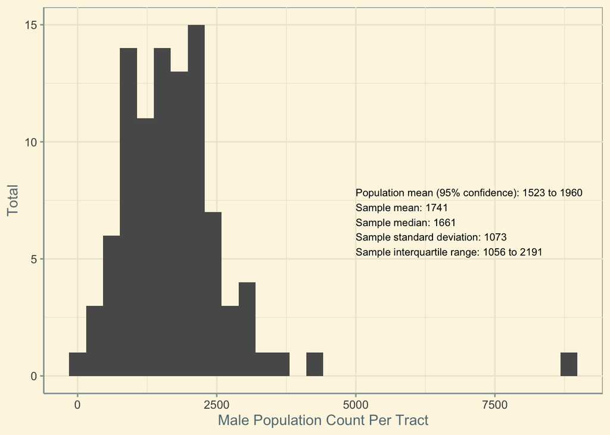

```r
hist2+
  theme_solarized() +
  scale_x_continuous(name = "Male Population Count Per Tract") +
  scale_y_continuous(name = "Total") +
  annotate("text", x = 5000, y = 8, size = 3,
           label = paste("Population mean (95% confidence):",
                         prettyNum(pop_mean2$conf.int[1], digits = 0),
                         "to",
                         prettyNum(pop_mean2$conf.int[2], digits = 0),

                         "\nSample mean:",
                         prettyNum(mean(male_popE), digits = 0),
                         "\nSample median:",
                         prettyNum(median(male_popE), digits = 0),
                         "\nSample standard deviation:",
                         prettyNum(sd(male_popE), digits = 0),
                         "\nSample interquartile range:",
                         prettyNum(quantile(male_popE)["25%"], digits = 0),
                         "to",
                         prettyNum(quantile(male_popE)["75%"], digits = 0)),
           hjust = 0, vjust = 1)
```

This outlier at 8,000 causing the right skew on this histogram has an interesting explanation! At first I thought it might be a problem with the data to see a male population outlier like this without a similar female one as well. Then I checked that dataset which confirmed my suspicions: there is a large incarcerated male population at High Desert Prison in Lassen County that must be included in this count.

### Population Below 100% Poverty Level Summary Stats and Distribution

```r
summary(poverty_100E)
```

```
##    Min. 1st Qu.  Median    Mean 3rd Qu.    Max.
##     0.0   308.0   473.0   558.1   709.0  1901.0
```

```r
sd(poverty_100E)
```

```
## [1] 373.4681
```

```r
pop_mean3 <- t.test(poverty_100E)
pop_mean3
```

```
##
##  One Sample t-test
##
## data:  poverty_100E
## t = 14.566, df = 94, p-value < 2.2e-16
## alternative hypothesis: true mean is not equal to 0
## 95 percent confidence interval:
##  482.0575 634.2162
## sample estimates:
## mean of x
##  558.1368
```

```r
hist3<- ggplot(Jefferson_tract_data, aes(x = poverty_100E)) +
  geom_histogram()
```

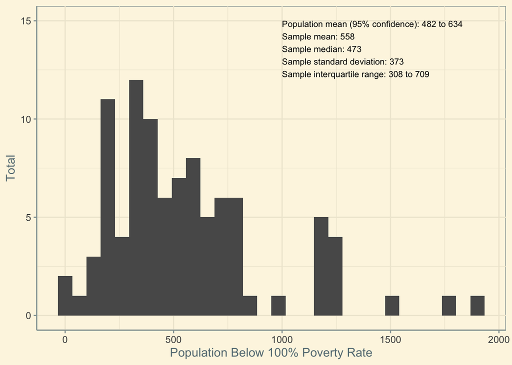

```r
hist3+
  theme_solarized() +
  scale_x_continuous(name = "Population Below 100% Poverty Rate") +
  scale_y_continuous(name = "Total") +
  annotate("text", x = 1000, y = 15, size = 3,
           label = paste("Population mean (95% confidence):",
                         prettyNum(pop_mean3$conf.int[1], digits = 0),
                         "to",
                         prettyNum(pop_mean3$conf.int[2], digits = 0),

                         "\nSample mean:",
                         prettyNum(mean(poverty_100E), digits = 0),
                         "\nSample median:",
                         prettyNum(median(poverty_100E), digits = 0),
                         "\nSample standard deviation:",
                         prettyNum(sd(poverty_100E), digits = 0),
                         "\nSample interquartile range:",
                         prettyNum(quantile(poverty_100E)["25%"], digits = 0),
                         "to",
                         prettyNum(quantile(poverty_100E)["75%"], digits = 0)),
           hjust = 0, vjust = 1)
```

This distribution is also skewed right a fair it. I’m curious if this also is related to the incarerated population in Lassen County. Understanding how census data is gathered might enable further exploration of the skews in this dataset.

### Poulation Between 100 and 149 % Poverty Level Summary Stats and Distribution

```r
summary(poverty_149E)
```

```
##    Min. 1st Qu.  Median    Mean 3rd Qu.    Max.
##     0.0   173.5   299.0   326.1   442.0   980.0
```

```r
sd(poverty_149E)
```

```
## [1] 201.0147
```

```r
pop_mean4 <- t.test(poverty_149E)
pop_mean4
```

```
##
##  One Sample t-test
##
## data:  poverty_149E
## t = 15.814, df = 94, p-value < 2.2e-16
## alternative hypothesis: true mean is not equal to 0
## 95 percent confidence interval:
##  285.1880 367.0856
## sample estimates:
## mean of x
##  326.1368
```

```r
hist4 <- ggplot(Jefferson_tract_data, aes(x = poverty_149E)) +
  geom_histogram()
```

[figure not shown]

```r
hist4+
  theme_solarized() +
  scale_x_continuous(name = "Population Between 100-149% Poverty Rate") +
  scale_y_continuous(name = "Total") +
  annotate("text", x = 500, y = 13, size = 3,
           label = paste("Population mean (95% confidence):",
                         prettyNum(pop_mean4$conf.int[1], digits = 0),
                         "to",
                         prettyNum(pop_mean4$conf.int[2], digits = 0),

                         "\nSample mean:",
                         prettyNum(mean(poverty_100E), digits = 0),
                         "\nSample median:",
                         prettyNum(median(poverty_100E), digits = 0),
                         "\nSample standard deviation:",
                         prettyNum(sd(poverty_100E), digits = 0),
                         "\nSample interquartile range:",
                         prettyNum(quantile(poverty_100E)["25%"], digits = 0),
                         "to",
                         prettyNum(quantile(poverty_100E)["75%"], digits = 0)),
           hjust = 0, vjust = 1)
```

I’m intrested in the overall shape of these poverty distributions across all of my poverty and public assistance datasets. I’d have to research further, but the outliers in each one could be associated with the outlier in the male population.

### Population over 150% Poverty Rate Summary Stats and Distribution

```r
summary(poverty_150E)
```

```
##    Min. 1st Qu.  Median    Mean 3rd Qu.    Max.
##       0    1424    2289    2321    3050    5632
```

```r
sd(poverty_150E)
```

```
## [1] 1166.272
```

```r
pop_mean5 <- t.test(poverty_150E)
pop_mean5
```

```
##
##  One Sample t-test
##
## data:  poverty_150E
## t = 19.395, df = 94, p-value < 2.2e-16
## alternative hypothesis: true mean is not equal to 0
## 95 percent confidence interval:
##  2083.218 2558.382
## sample estimates:
## mean of x
##    2320.8
```

```r
hist5 <- ggplot(Jefferson_tract_data, aes(x = poverty_150E)) +
  geom_histogram()
```

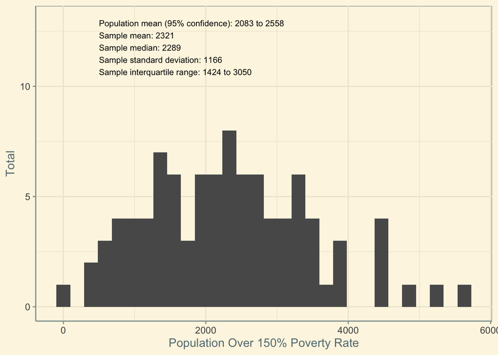

```r
hist5+
  theme_solarized() +
  scale_x_continuous(name = "Population Over 150% Poverty Rate") +
  scale_y_continuous(name = "Total") +
  annotate("text", x = 500, y = 13, size = 3,
           label = paste("Population mean (95% confidence):",
                         prettyNum(pop_mean5$conf.int[1], digits = 0),
                         "to",
                         prettyNum(pop_mean5$conf.int[2], digits = 0),

                         "\nSample mean:",
                         prettyNum(mean(poverty_150E), digits = 0),
                         "\nSample median:",
                         prettyNum(median(poverty_150E), digits = 0),
                         "\nSample standard deviation:",
                         prettyNum(sd(poverty_150E), digits = 0),
                         "\nSample interquartile range:",
                         prettyNum(quantile(poverty_150E)["25%"], digits = 0),
                         "to",
                         prettyNum(quantile(poverty_150E)["75%"], digits = 0)),
           hjust = 0, vjust = 1)
```

### Population Receiving Public Assistance Summary Stats and Distribution

```r
summary(pub_assistE)
```

```
##    Min. 1st Qu.  Median    Mean 3rd Qu.    Max.
##     0.0   884.5  1300.0  1331.8  1734.0  3223.0
```

```r
sd(pub_assistE)
```

```
## [1] 610.3776
```

```r
pop_mean6 <- t.test(pub_assistE)
pop_mean6
```

```
##
##  One Sample t-test
##
## data:  pub_assistE
## t = 21.267, df = 94, p-value < 2.2e-16
## alternative hypothesis: true mean is not equal to 0
## 95 percent confidence interval:
##  1207.502 1456.182
## sample estimates:
## mean of x
##  1331.842
```

```r
hist6 <- ggplot(Jefferson_tract_data, aes(x = pub_assistE)) +
  geom_histogram()
```

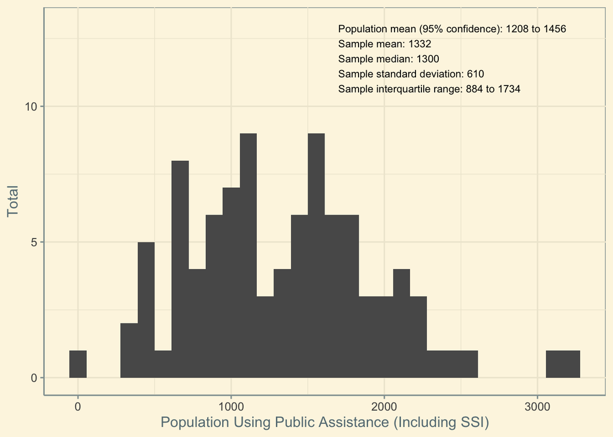

```r
hist6+
  theme_solarized() +
  scale_x_continuous(name = "Population Using Public Assistance (Including SSI)") +
  scale_y_continuous(name = "Total") +
  annotate("text", x = 1700, y = 13, size = 3,
           label = paste("Population mean (95% confidence):",
                         prettyNum(pop_mean6$conf.int[1], digits = 0),
                         "to",
                         prettyNum(pop_mean6$conf.int[2], digits = 0),

                         "\nSample mean:",
                         prettyNum(mean(pub_assistE), digits = 0),
                         "\nSample median:",
                         prettyNum(median(pub_assistE), digits = 0),
                         "\nSample standard deviation:",
                         prettyNum(sd(pub_assistE), digits = 0),
                         "\nSample interquartile range:",
                         prettyNum(quantile(pub_assistE)["25%"], digits = 0),
                         "to",
                         prettyNum(quantile(pub_assistE)["75%"], digits = 0)),
           hjust = 0, vjust = 1)
```

The more even distributions of values in this dataset compared to the following where SSI is excluded makes sense given the older age averages of people in the rural Jefferson region who might be utilizing SSI.

### Population Receiving Public Assistance (cash or food stamps) Summary Stats and Distribution

```r
summary(cash_assistE)
```

```
##    Min. 1st Qu.  Median    Mean 3rd Qu.    Max.
##     0.0    72.5   139.0   161.8   215.0   600.0
```

```r
sd(cash_assistE)
```

```
## [1] 119.6868
```

```r
pop_mean7 <- t.test(cash_assistE)
pop_mean7
```

```
##
##  One Sample t-test
##
## data:  cash_assistE
## t = 13.175, df = 94, p-value < 2.2e-16
## alternative hypothesis: true mean is not equal to 0
## 95 percent confidence interval:
##  137.3975 186.1604
## sample estimates:
## mean of x
##  161.7789
```

```r
hist7 <- ggplot(Jefferson_tract_data, aes(x = cash_assistE)) +
  geom_histogram()
```

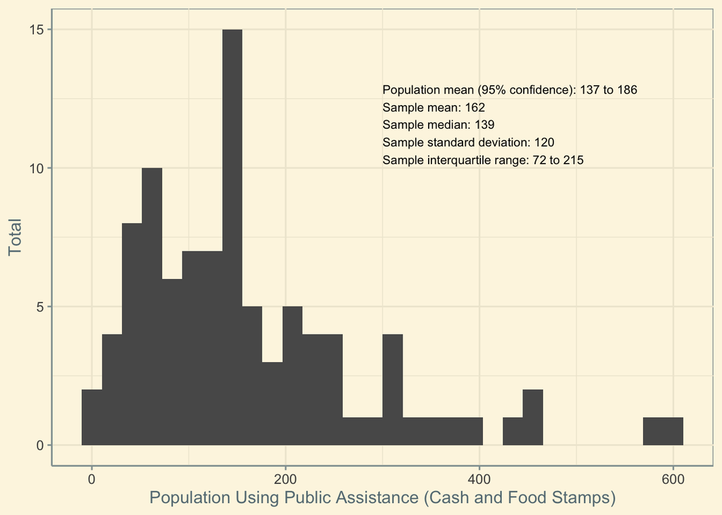

```r
hist7+
  theme_solarized() +
  scale_x_continuous(name = "Population Using Public Assistance (Cash and Food Stamps)") +
  scale_y_continuous(name = "Total") +
  annotate("text", x = 300, y = 13, size = 3,
           label = paste("Population mean (95% confidence):",
                         prettyNum(pop_mean7$conf.int[1], digits = 0),
                         "to",
                         prettyNum(pop_mean7$conf.int[2], digits = 0),

                         "\nSample mean:",
                         prettyNum(mean(cash_assistE), digits = 0),
                         "\nSample median:",
                         prettyNum(median(cash_assistE), digits = 0),
                         "\nSample standard deviation:",
                         prettyNum(sd(cash_assistE), digits = 0),
                         "\nSample interquartile range:",
                         prettyNum(quantile(cash_assistE)["25%"], digits = 0),
                         "to",
                         prettyNum(quantile(cash_assistE)["75%"], digits = 0)),
           hjust = 0, vjust = 1)
```

Again, the outlier here seems to conicde with the male population outlier causing the histogram to skew right. The spike in this dataset is also seen in several of the histograms above. I’m not sure what this is showing. It could be caused by a tract count with a much higher population count than others in the rural region.

### Population Not Receiving Public Assistance Summary Stats and Distribution

```r
summary(no_assistE)
```

```
##    Min. 1st Qu.  Median    Mean 3rd Qu.    Max.
##       0     845    1228    1281    1668    3192
```

```r
sd(no_assistE)
```

```
## [1] 588.0004
```

```r
pop_mean8 <- t.test(no_assistE)
pop_mean8
```

```
##
##  One Sample t-test
##
## data:  no_assistE
## t = 21.241, df = 94, p-value < 2.2e-16
## alternative hypothesis: true mean is not equal to 0
## 95 percent confidence interval:
##  1161.639 1401.203
## sample estimates:
## mean of x
##  1281.421
```

```r
hist8 <- ggplot(Jefferson_tract_data, aes(x = no_assistE)) +
  geom_histogram()
```

[figure not shown]

```r
hist8+
  theme_solarized() +
  scale_x_continuous(name = "Population Not Receiving Public Assistance") +
  scale_y_continuous(name = "Total") +
  annotate("text", x = 1700, y = 13, size = 3,
           label = paste("Population mean (95% confidence):",
                         prettyNum(pop_mean8$conf.int[1], digits = 0),
                         "to",
                         prettyNum(pop_mean8$conf.int[2], digits = 0),

                         "\nSample mean:",
                         prettyNum(mean(poverty_100E), digits = 0),
                         "\nSample median:",
                         prettyNum(median(poverty_100E), digits = 0),
                         "\nSample standard deviation:",
                         prettyNum(sd(poverty_100E), digits = 0),
                         "\nSample interquartile range:",
                         prettyNum(quantile(poverty_100E)["25%"], digits = 0),
                         "to",
                         prettyNum(quantile(poverty_100E)["75%"], digits = 0)),
           hjust = 0, vjust = 1)
```

### Categorical Variable Calculation: Jefferson

My categorical variables for this dataset are county, region, and whether or not the tract meets/exceeds or is below the statewide average HS graduation rate of 83%. I’ve only performed caluclations on HS graduation rate here because the county and region variables are set and cannot be estimated or calculated.

```r
meets_hs_grads <- t.test(majority_hs_grads)
below_hs_grads <- t.test(!majority_hs_grads)
```

```r
grads_shares <- tibble(Diplomas = c("Meets Statewise Average",
                                    "Below Statewide Average"),
                     `Sample` =c(paste(prettyNum(meets_hs_grads$estimate*100,
                                         digits = 3), "%"),
                         paste(prettyNum(below_hs_grads$estimate*100,
                                         digits = 3), "%")),
                      `95-percent confidence interval` =
                        c(paste(prettyNum(meets_hs_grads$conf.int[1]*100,
                                          digits = 3), "% to ",
                                prettyNum(meets_hs_grads$conf.int[2]*100,
                                          digits = 3), "%"),
                         paste(prettyNum(below_hs_grads$conf.int[1]*100,
                                          digits = 3), "% to ",
                                prettyNum(below_hs_grads$conf.int[2]*100,
                                          digits = 3), "%")))
knitr::kable(grads_shares, caption = "Census Tracts in Jefferson Region")
```

Census Tracts in Jefferson Region

[output not shown]

### Calculations and Distributions for Bay Area Region